# Barnes et al: Predator and Prey Bodysizes in Marine Food Webs

Felix Carter

27/10/2020

## Background Information

The abstract of this paper explains that we need information of the relationships between predator and prey size in order to understand how species and size classes interact within food webs. This data contains almost 35,000 records from a range of environments and locations, for a vast range of predator sizes - from 0.1 milligrams to 415 kilograms, and prey sizes from 75 picograms to over 4.5 kilograms. Information about the species such as location, scientific name, life stage and habitat description is also included.

## Importing the Data

Firstly, I had to download the text file containing the data from the 2008 Barnes et al. study(the data can be found at https://figshare.com/articles/dataset/Full_Archive/3529112). Then I converted it to a .csv file in Excel. In this code, we import the library tidyverse to use its features (including ggplot) in the future. Then we import the data file into R and save it to the pred_prey_data dataframe.

```r
library(tidyverse)
pred_prey_data <- read.csv("Predator_and_prey_body_sizes_in_marine_food_webs_vsn4_csvcopy.csv")
```

## Starting to look at the data

Plotting masses of the prey masses shows the variation in the data.

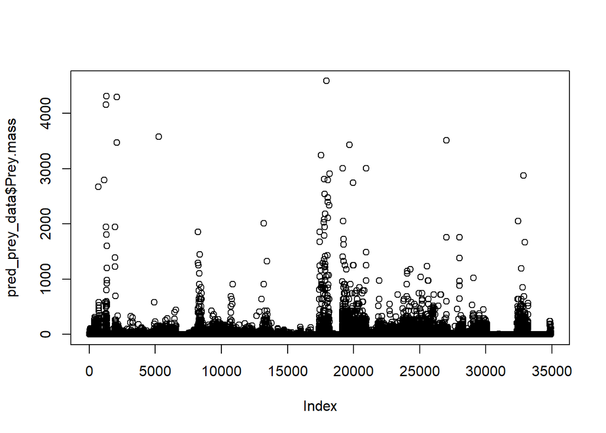

```r
plot(pred_prey_data$Prey.mass)
```

This graph shows that most of the data entries are under 1000 units for Prey.mass, however some of them are over 4000 units. We can view the units for this variable:

```r
unique(pred_prey_data$Prey.mass.unit)
```

```
## [1] "g"  "mg"
```

```r
unique(pred_prey_data$Predator.mass.unit)
```

```
## [1] "g"
```

Which shows that for Prey Mass as in the graph above, some masses are measured in milligrams but some are measured in grams. Fortunately, for Predator Mass all units are in grams. Ideally we would like to get all measurements in the same unit (grams) for fair comparison in graphs. In the code below, we multiply any Prey Mass measurement that is in milligrams by 0.001 to convert it to grams. We then set the mass unit value to grams for these to “g” so this is accurate.

```r
pred_prey_data$Prey.mass[pred_prey_data$Prey.mass.unit == "mg"] <- 0.001*pred_prey_data$Prey.mass[pred_prey_data$Prey.mass.unit == "mg"]
pred_prey_data$Prey.mass.unit[pred_prey_data$Prey.mass.unit == "mg"] <- "g"
```

We can now see that all measurements for Prey mass are in grams:

```r
unique(pred_prey_data$Prey.mass.unit) #shows now all in grams
```

```
## [1] "g"
```

We have now got data on predator/prey masses we can work with for comparisons.

## Predator and Prey Mass data

Now assign the data for Predator and Prey mass in grams to new data frames:

```r
pred_mass_g <-pred_prey_data$Predator.mass #all in grams anyway
prey_mass_g <-pred_prey_data$Prey.mass # now all converted to grams
```

We can view summaries of the data for Predator Mass and Prey Mass:

```r
summary(pred_mass_g)
```

```
##    Min. 1st Qu.  Median    Mean 3rd Qu.    Max.
##       0     172    1751   15292    6326  415600
```

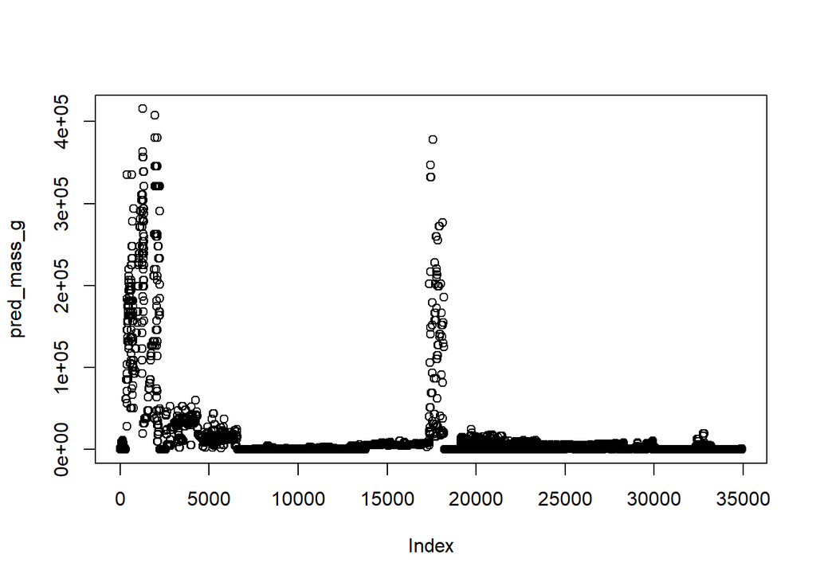

```r
plot(pred_mass_g)
```

This shows that whilst the average predator has a mass of about 15,000g, there are some predators that have a mass of up to 415,600g.

Now if we wanted to compare the mass of a predator with the mass of its prey, we could do this using the ggplot function, which has more features than the inbuilt plot function:

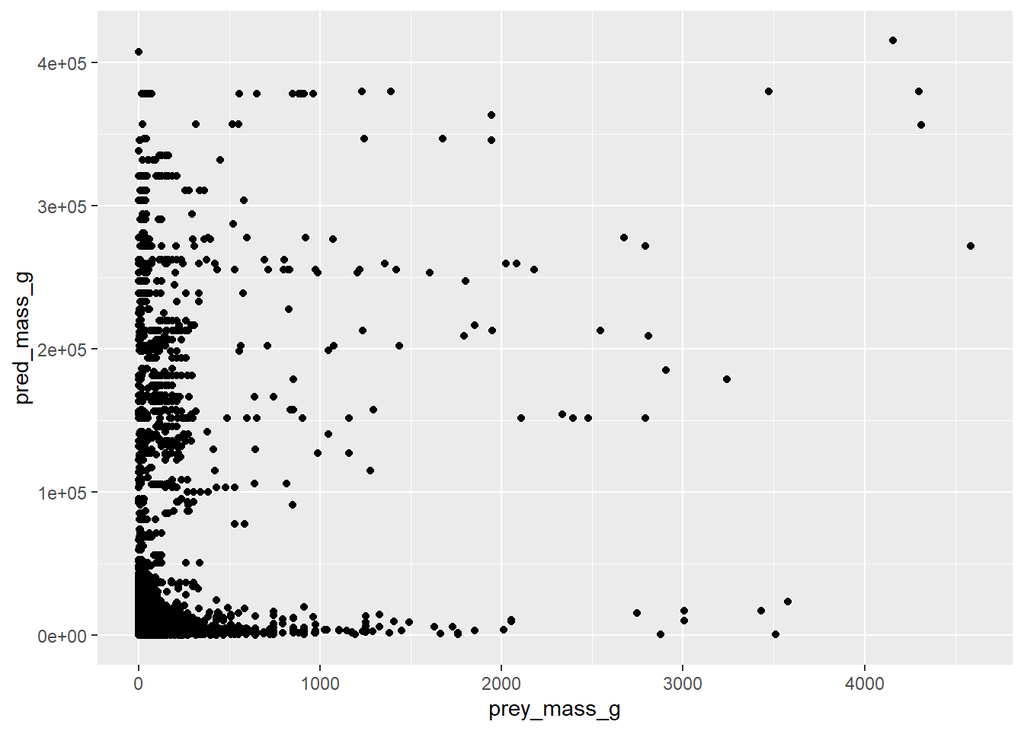

```r
pred_prey_data %>%
  ggplot(aes(x= prey_mass_g, y= pred_mass_g)) +
  geom_point()
```

Its hard to draw conclusions from this graph because of the scale of the graph - most values are clustered towards the lower end of the mass scale. If we take the log of both sides, this should represent the data in a better way visually:

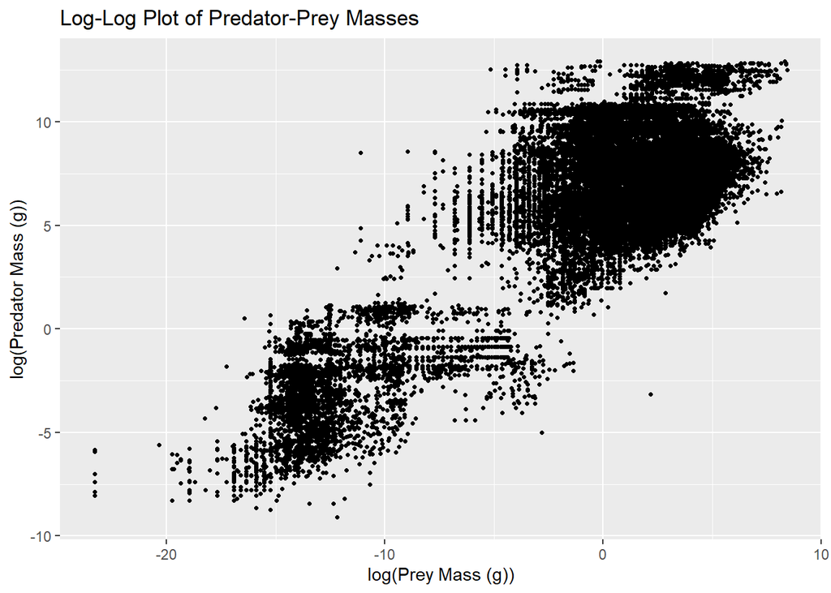

```r
pred_prey_data %>%
  ggplot(aes(x= log(prey_mass_g), y= log(pred_mass_g))) +
  geom_point(shape=20) +
  ggtitle("Log-Log Plot of Predator-Prey Masses") +
  xlab("log(Prey Mass (g))") +
  ylab("log(Predator Mass (g))")
```

(Note we have added titles and labels to the graph, and made the scatterpoints smaller so they can be differentiated more easily). As we can see from this graph, there appears to be a correlation between the natural logarithm of predator mass and the natural logarithm of prey mass. This implies that the masses follow a power law relationship, i.e the function is of the form y=a*x^b. We can also see that the data appears to be in two distinct ‘clusters’ - one at the lower end of the log-log scale, and one at the higher end.

Viewing Fig. 1 of the metadata file that accompanied the data, we see that they plotted a log10-log10 graph rather than using natural logarithms, so we can do this in future.

Now, lets try and infer the power law relationship from this data.

```r
log10fit=lm(log10(pred_mass_g)~log10(prey_mass_g),data=pred_prey_data)
summary(log10fit)
```

```
##
## Call:
## lm(formula = log10(pred_mass_g) ~ log10(prey_mass_g), data = pred_prey_data)
##
## Residuals:
##     Min      1Q  Median      3Q     Max
## -4.9165 -0.8269 -0.0636  0.9629  3.9984
##
## Coefficients:
##                    Estimate Std. Error t value Pr(>|t|)
## (Intercept)        2.921741   0.005789   504.7   <2e-16 ***
## log10(prey_mass_g) 0.656835   0.002487   264.1   <2e-16 ***
## ---
## Signif. codes:  0 '***' 0.001 '**' 0.01 '*' 0.05 '.' 0.1 ' ' 1
##
## Residual standard error: 1.069 on 34929 degrees of freedom
## Multiple R-squared:  0.6663, Adjusted R-squared:  0.6663
## F-statistic: 6.973e+04 on 1 and 34929 DF,  p-value: < 2.2e-16
```

We can add this line to our logarithmic graph (in red), as well as a 1:1 line (in black) for visual purposes.

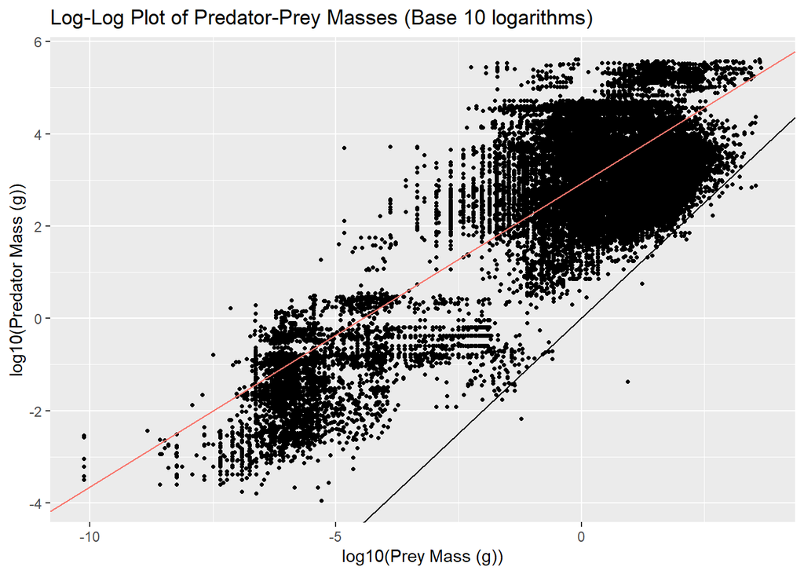

```r
pred_prey_data %>%
  ggplot(aes(x= log10(prey_mass_g), y= log10(pred_mass_g))) +
  geom_point(shape=20) +
  ggtitle("Log-Log Plot of Predator-Prey Masses (Base 10 logarithms)") +
  xlab("log10(Prey Mass (g))") +
  ylab("log10(Predator Mass (g))") +
  geom_abline(aes(slope = 1,intercept = 0)) +
  geom_abline(aes(slope = 0.656835,intercept = 2.921741, color="red"), show.legend=FALSE)
```

The line in red for the logarithmic version of the power law relationship does seem to fit our dataset, suggesting that this is a good approximate law for this data.

The metadata file for the 2008 Barnes et al. study that this dataset is from states that about 99.4% of data is above the 1:1 line (or below if plotting prey mass on y axis, predator mass on x axis). We can see on the graph above that almost all of our datapoints are above the black 1:1 line so follow this relationship. This is to be expected - the mass of the predator is almost always greater than the mass of the prey.

## Looking at Barnes et al.’s 2010 study using the same data

Looking at a similar paper from two years later, also from Barnes et al., “Global patterns in predator—prey size relationships reveal size dependency of trophic transfer efficiency” (https://www.jstor.org/stable/25661038) reveals the significance of the Predator-Prey Mass Ratio (PPMR), which isn’t a variable in the dataset we are currently interpreting. However, this 2010 paper uses this dataset to draw its conclusions, and we can calculate (individual-link) PPMR by dividing predator mass by prey mass as follows:

```r
PPMR <- pred_mass_g/prey_mass_g
```

In the 2010 Barnes et al. study, they plotted PPMR against predator mass, like this:

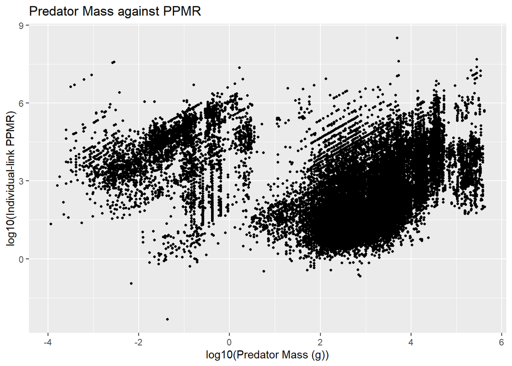

```r
pred_prey_data %>%
  ggplot(aes(x= log10(pred_mass_g), y= log10(PPMR))) +
  geom_point(shape=20) +
  ggtitle("Predator Mass against PPMR") +
  xlab("log10(Predator Mass (g))") +
  ylab("log10(Individual-link PPMR)")
```